# Estimation

Paul Schrimpf

2026-09-28

## Reading

- Required: **Song (2021) chapter 4, sections 1.2 and 2** (which is the basis for these slides)
- Supplemental: Lehmann and Romano (n.d.) , Lehmann and Casella (2006)

$$\def\Er{{\mathrm{E}}}
\def\cov{{\mathrm{Cov}}}
\def\var{{\mathrm{Var}}}
\def\R{{\mathbb{R}}}$$

# Estimation

## Estimator

- Given a parameter of interest $\theta_0$, an **estimator** is a measurable function of an observed random vector X, i.e. $\hat{\theta} = \tau(X)$ for some known map $\tau$
- An **estimate** given $X=x$ is $\tau(x)$

## Sample Analogue Estimation

- i.i.d. observations from $P$, $X = (X_1, ...., X_n)$
- constructively identified parameter $\theta_0 = \psi(P)$
- empirical measure:
  $$\hat{P}(B) = \frac{1}{n} \sum_{i=1}^n 1\{X_i \in B \}.$$
- Sample analogue estimator
  $$\hat{\theta} = \psi(\hat{P})$$

## Sample Analogue Estimation - Examples

- Mean
- OLS

## Maximum Likelihood Estimation

- $X \in \R^n$ distribution $P_X \in \mathcal{P} = \{P_\theta: \theta \in \Theta \subset \R^d \}$
- $P_\theta$ dominated by $\sigma$-finite $\mu$ with density $f_X(\cdot;\theta)$
- **Likelihood** $\ell(\cdot, X): \Theta \to [0,\infty)$
  $$\ell(\theta; X)= f(X; \theta)$$
- **Maximum likelihood estimator**
  $$\hat{\theta}_{MLE} = \textrm{arg}\max_{\theta \in \Theta} \ell(\theta;X)$$

## MLE: Example

- $X_i \sim N(\mu, 1)$

## MLE: Example

- $Y_i = \alpha_0 + \beta_0 X_i + \epsilon_i$, $\epsilon_i \sim N(0, \sigma_0^2)$

## MLE: Equivariance

**Theorem 1.1**

If $\hat{\theta}$ is the MLE of $\theta$, then for any function $g:\Theta \to G$, the MLE of $g(\theta)$ is $g(\hat{\theta})$.

# Quality of Estimators

## Loss and Risk

- **Loss function** $L: \R^d \times \Theta \to [0,\infty)$ with $L(\theta,\theta)=0$
- **Risk** of $\hat{\theta}$ at $\theta_0$ = $\Er[L(\hat{\theta}, \theta_0)]$

## Mean Squared Error

- Squared error loss $L_2(\theta, \theta_0) = (\theta-\theta_0)'(\theta-\theta_0)$
- Mean squared error
  $$MSE(\hat{\theta}) = \Er[ (\theta-\theta_0)'(\theta-\theta_0) ]$$
- Bias-variance decomposition
  $$MSE(\hat{\theta}) = \textrm{Bias}(\hat{\theta})'\textrm{Bias}(\hat{\theta}) + \textrm{tr}(\var(\hat{\theta}))$$

# Optimal Estimation in Parametric Models

## Setup

- $X \in \R^n$ distribution $P_X \in \mathcal{P} = \{P_\theta: \theta \in \Theta \subset \R^d \}$, likelihood $\ell(\theta;x) = f_X(x;\theta)$
- Question: if an estimator is unbiased, what is the smallest possible variance?

## Score Equality

- If $\frac{\partial}{\partial \theta} \int f_X(x;\theta) d\mu(x) = \int \frac{\partial}{\partial \theta} f_X(x;\theta) d\mu(x)$, then
  $$\int \underbrace{\frac{\partial \log \ell(\theta;x)}{\partial \theta}}_{\text{score}=s(x,\theta)} dP_\theta(x) = 0$$

## Information Equality

- Fischer Information $I(\theta) = \int s(x,\theta) s(x,\theta)' dP_\theta(x)$
- If $\frac{\partial^2}{\partial \theta\partial \theta'} \int f_X(x;\theta) d\mu(x) = \int \frac{\partial^2}{\partial \theta\partial \theta'} f_X(x;\theta) d\mu(x)$, then
  $$I(\theta) = -\int \underbrace{\frac{\partial^2 \log \ell(\theta;x)}{\partial \theta \partial \theta'}}_{\text{Hessian}=h(x,\theta)} dP_\theta(x)$$
- If $T = \tau(X)$ is an unbiased estimator for $\theta$ and
  $$\frac{\partial}{\partial \theta} \int \tau(x) f_X(x;\theta) d\mu(x) =
  \int \tau(x) \frac{\partial f_X(x,\theta)}{\partial \theta} d\mu(x)$$
  then
  $$\int \tau(x) s(x,\theta)'dP_\theta(x) = I$$

## Cramér-Rao Bound

**Cramér-Rao Bound**

Let $T = \tau(X)$ be an unbiased estimator, and suppose the condition of the previous slide and of the score equality hold. Then,
$$\var_\theta(\tau(X)) \equiv \int \left(\tau(x) - \int \tau(x) dP_\theta\right)\left(\tau(x) - \int \tau(x) dP_\theta\right)' dP\theta \geq I(\theta)^{-1}$$

# Hypothesis Testing

## Hypothesis Testing

- $X \in \mathcal{X} \subset \R^n$, distribution $P_x \in \mathcal{P}$
- Partition $\mathcal{P} = \mathcal{P}_0 \cup \mathcal{P}_1$
- Null and alternative hypotheses:
  - $H_0: \; P_x \in \mathcal{P}_0$
  - $H_1: \; P_x \in \mathcal{P}_1$

## Hypothesis Testing

- Test partitions $\mathcal{X} = \underbrace{C}_{\text{critical region}} \cup A$
  - Reject null if $X \in C$
  - Often $C = \{x \in \mathcal{X}: \underbrace{\tau(x)}_{\text{test statistic}} > \underbrace{c}_{\text{critical value}} \}$

## Hypothesis Testing

- $P(\text{reject } H_0 | P_x \in \mathcal{P}_0)$=*Type I error* $=P_x(C)$
- $P(\text{fail to reject } H_0 | P_x \in \mathcal{P}_1)$=*Type II error*
- $P(\text{reject } H_0 | P_x \in \mathcal{P}_1)$ = *power*
- $\sup_{P_x \in \mathcal{P}_0} P_x(C)$ = *size of test*

## p-value

- test statistic $\tau(X)$ , define
  $$G_{P_x}(t) = P_x(\tau(X) > t)$$
- Given observed data $\hat{X}$, *p-value* is
  $$p(\hat{X}) = \sup_{P_x \in \mathcal{P}_0} P_x(\tau(X) > \tau(\hat{X})) = \sup_{P_x \in \mathcal{P}_0} G_{P_x}(\tau(\hat{X}))$$
- if $\mathcal{P}_0 = \{P_0\}$, critical value $c$, let $\alpha = G_{P_0}(c)$, then $\tau(X) > c$ iff $p(\hat{X}) < \alpha$

## Testing in Parametric Family

- Parametric family $\mathcal{P} = \{P_\theta: \theta \in \Theta\}$
  - $\Theta_0 = \{\theta \in \Theta: P_\theta \in \mathcal{P}_0\}$
  - $\Theta_1 = \{\theta \in \Theta: P_\theta \in \mathcal{P}_1\}$
- Hypotheses
  - $H_0 : \theta \in \Theta_0$
  - $H_1: \theta \in \Theta_1$
- **Power function** of test $C$
  $$\pi:\Theta \to [0,1] , \;\; \pi(\theta) = P_\theta(C)$$
- Size $= \sup_{\theta \in \Theta_0} \pi(\theta)$

## Example: Testing in Parametric Family

- $\mathcal{P} = \{ P_\mu(A) = \int_A \frac{1}{\sqrt{2\pi}} e^{-(x-\mu)^2/2} dx : \mu \in \in \R \}$
- $\Theta_0 = [-a,a]$
- $\Theta_1 = (-\infty,-a) \cup (a,\infty)$
- $C(X;c) = \max\{\frac{1}{n} \sum_{i=1}^n x_i - a, 0\} + \max \{-\frac{1}{n} \sum_{i=1}^n x_i + a, 0\} > c$

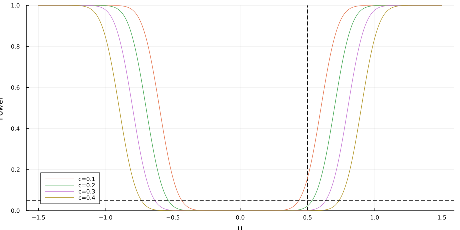

## More Powerful

**Definition**

- For test $C_1$ and $C_2$ with same size, $C_1$ is **more powerful** at $\theta \in \Theta_1$ than $C_2$ if $P_\theta(C_1) \geq P_\theta(C_2)$
- $C$ is **most powerful** at $\theta \in \Theta_1$ if it is more powerful than any test of the same size
- $C$ is **uniformly most powerful** if it is most powerful at any $\theta \in \Theta_1$

## Example: Power Comparisons

- Same setup as previous figure, but consider tests
  $$\begin{align*}
  C(X;c) = & \max\{\frac{1}{n} \sum_{i=1}^n x_i - a, 0\} + \max
  \{-\frac{1}{n} \sum_{i=1}^n x_i +a, 0\} > c \\
  \tilde{C}(x;c) = & \sum_{i=1}^n 1\{x_i > a\} + 1\{x_i < -a\} > c
  \end{align*}$$

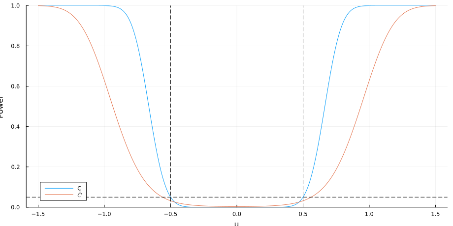

## Neyman-Pearson

**Lemma (Neyman-Pearson)**

Let $\Theta = \{0, 1\}$, $f_0$ and $f_1$ be densities of $P_0$ and $P_1$, $\tau(x) =f_1(x)/f_0(x)$ and $C^* =\{x \in X: \tau(x) > c\}$. Then among all tests $C$ s.t. $P_0(C) = P_0(C^*)$, $C^*$ is most powerful.

## Example

- $X_i \sim N(\mu, 1)$
- $H_0: \mu = 0$ against $H_1: \mu = 1$
- Find a most powerful test
- What is the most powerful test if $H_1: \mu = a$ for $a>0$ instead?
- What is the uniformly most powerful test if $H_1: \mu > 0$ ?
- What is the uniformly most powerful test if $H_1: \mu \neq 0$ ?

# References

Lehmann, Erich L, and George Casella. 2006. *Theory of Point Estimation*. Springer Science & Business Media. https://link.springer.com/book/10.1007/b98854.

Lehmann, Erich Leo, and Joseph P Romano. n.d. *Testing Statistical Hypotheses*. Vol. 3. Springer. https://link.springer.com/book/10.1007/0-387-27605-X.

Song, Kyunchul. 2021. *Introduction to Econometrics*.